# Portfoliomanagement and Financial Analysis - Assignment 3

## Exercise 2: Do it yourself

In this exercise you first download the IBoxx Euro Corporate All Maturities (“IBCRPAL”) and the EuroStoxx (“DJES50I”) index from Datastream - monthly data as long as possible. We will check the calculations of `R`. Calculate discrete monthly returns.

downloaded it from datastream –> citrix (Thomson Reuters)

uploaded it on the right side –> as a excel (xlsx)

import dataset on the right side above –> the two of them

```r
Eurostoxx_correct <- read_xlsx("eurostoxx.xlsx")
Eurostoxx_correct
```

| date | price |
| --- | --- |
| 1998-12-31 | 3342.320 |
| 1999-01-29 | 3547.150 |
| 1999-02-26 | 3484.240 |
| 1999-03-31 | 3559.860 |
| 1999-04-30 | 3757.870 |
| 1999-05-31 | 3629.460 |
| 1999-06-30 | 3788.660 |
| 1999-07-30 | 3638.620 |
| 1999-08-31 | 3769.140 |
| 1999-09-30 | 3669.710 |

[output cut: 251 more lines]

```r
View(Eurostoxx_correct)

Iboxx_correct <- read_xlsx("iboxx.xlsx")
Iboxx_correct
```

| date | price |
| --- | --- |
| 1998-12-31 | 100.000 |
| 1999-01-31 | 100.911 |
| 1999-02-28 | 98.742 |
| 1999-03-31 | 99.328 |
| 1999-04-30 | 100.292 |
| 1999-05-31 | 98.300 |
| 1999-06-30 | 96.115 |
| 1999-07-31 | 94.343 |
| 1999-08-31 | 93.524 |
| 1999-09-30 | 92.396 |

[output cut: 251 more lines]

```r
View(Iboxx_correct)
```

Calculate monthly returns for eurostoxx

```r
monthly_returns_eurostoxx <- Eurostoxx_correct %>%
  mutate(date=as.yearmon(date), price=as.numeric(price))%>%
  tq_transmute(select = price,
               mutate_fun = periodReturn,
               period="monthly",
               type="arithmetic",
               col_rename = "monthly_returns"
               )
monthly_returns_eurostoxx
```

| date | monthly_returns |
| --- | --- |
| Dec 1998 | 0.000000e+00 |
| Jan 1999 | 6.128378e-02 |
| Feb 1999 | -1.773537e-02 |
| Mar 1999 | 2.170344e-02 |
| Apr 1999 | 5.562297e-02 |
| May 1999 | -3.417095e-02 |
| Jun 1999 | 4.386327e-02 |
| Jul 1999 | -3.960239e-02 |
| Aug 1999 | 3.587074e-02 |
| Sep 1999 | -2.638002e-02 |

[output cut: 251 more lines]

```r
NA
NA
```

then the same for iboxx

```r
monthly_returns_iboxx <- Iboxx_correct %>%
  mutate(date=as.yearmon(date), price=as.numeric(price)) %>%
  tq_transmute(select = price,
               mutate_fun = periodReturn,
               period="monthly",
               type="arithmetic",
               col_rename = "monthly_returns"
               )

monthly_returns_iboxx
```

| date | monthly_returns |
| --- | --- |
| Dec 1998 | 0.000000e+00 |
| Jan 1999 | 9.110000e-03 |
| Feb 1999 | -2.149419e-02 |
| Mar 1999 | 5.934658e-03 |
| Apr 1999 | 9.705219e-03 |
| May 1999 | -1.986200e-02 |
| Jun 1999 | -2.222787e-02 |
| Jul 1999 | -1.843625e-02 |
| Aug 1999 | -8.681089e-03 |
| Sep 1999 | -1.206108e-02 |

[output cut: 251 more lines]

```r
NA
```

to use portfolioanalytics package we need our data in xts format

```r
eurostoxx_returns_xts <- monthly_returns_eurostoxx %>%
  select(date,monthly_returns) %>%
  tk_xts(silent = TRUE)
eurostoxx_returns_xts
```

```
         monthly_returns
Dec 1998    0.000000e+00
Jan 1999    6.128378e-02
Feb 1999   -1.773537e-02
Mar 1999    2.170344e-02
Apr 1999    5.562297e-02
May 1999   -3.417095e-02
Jun 1999    4.386327e-02
Jul 1999   -3.960239e-02
Aug 1999    3.587074e-02
Sep 1999   -2.638002e-02
Oct 1999    6.899728e-02
Nov 1999    9.979046e-02
Dec 1999    1.367701e-01
Jan 2000   -4.485308e-02
Feb 2000    1.063384e-01
Mar 2000    1.291432e-02
Apr 2000    1.036318e-02
May 2000   -1.943118e-02
Jun 2000   -1.067876e-02
Jul 2000   -4.382794e-03
Aug 2000    1.021317e-02
Sep 2000   -5.022824e-02
Oct 2000    2.894645e-02
Nov 2000   -5.286827e-02
Dec 2000   -3.693259e-03
Jan 2001    1.573846e-03
Feb 2001   -9.644955e-02
Mar 2001   -3.099855e-02
Apr 2001    8.124444e-02
May 2001   -2.182759e-02
Jun 2001   -4.119345e-02
Jul 2001   -3.594000e-02
Aug 2001   -8.491267e-02
Sep 2001   -1.194748e-01
Oct 2001    5.519829e-02
Nov 2001    5.164102e-02
Dec 2001    4.041801e-02
Jan 2002   -3.569768e-02
Feb 2002   -1.240239e-02
```

[output cut: 207 more lines]

```
Jun 2019    5.891521e-02
Jul 2019   -1.970237e-03
Aug 2019   -1.156266e-02
Sep 2019    4.163959e-02
Oct 2019    9.794781e-03
Nov 2019    2.751321e-02
Dec 2019    1.122481e-02
Jan 2020   -2.783490e-02
Feb 2020   -8.553304e-02
Mar 2020   -1.629639e-01
Apr 2020    5.060275e-02
May 2020    4.175887e-02
Jun 2020    6.028170e-02
Jul 2020   -1.847519e-02
Aug 2020    3.093390e-02
```

```r
iboxx_returns_xts <- monthly_returns_iboxx %>%
  select(date,monthly_returns) %>%
  tk_xts(silent = TRUE)
iboxx_returns_xts
```

```
         monthly_returns
Dec 1998    0.000000e+00
Jan 1999    9.110000e-03
Feb 1999   -2.149419e-02
Mar 1999    5.934658e-03
Apr 1999    9.705219e-03
May 1999   -1.986200e-02
Jun 1999   -2.222787e-02
Jul 1999   -1.843625e-02
Aug 1999   -8.681089e-03
Sep 1999   -1.206108e-02
Oct 1999   -1.926490e-03
Nov 1999    3.112191e-03
Dec 1999   -1.081023e-02
Jan 2000   -7.431288e-03
Feb 2000    4.183870e-04
Mar 2000    9.993066e-03
Apr 2000   -6.570703e-03
May 2000   -4.848192e-03
Jun 2000   -2.953949e-03
Jul 2000    2.763714e-03
Aug 2000   -2.734048e-03
Sep 2000    1.746628e-03
Oct 2000   -2.659516e-03
Nov 2000    7.468714e-03
Dec 2000    1.171858e-02
Jan 2001    9.943660e-03
Feb 2001   -4.944376e-04
Mar 2001    3.688608e-03
Apr 2001   -1.111087e-02
May 2001    7.714394e-03
Jun 2001   -1.171955e-03
Jul 2001    1.052768e-02
Aug 2001    6.029230e-03
Sep 2001   -1.247326e-02
Oct 2001    2.305284e-02
Nov 2001   -6.665688e-03
Dec 2001   -1.277723e-02
Jan 2002   -8.550023e-05
Feb 2002   -6.252739e-03
```

[output cut: 207 more lines]

```
Jun 2019    1.663234e-02
Jul 2019    1.088994e-02
Aug 2019    5.261048e-03
Sep 2019   -8.951802e-03
Oct 2019   -4.385568e-03
Nov 2019   -3.556238e-03
Dec 2019   -2.037940e-03
Jan 2020    1.049498e-02
Feb 2020   -5.147746e-03
Mar 2020   -7.144084e-02
Apr 2020    3.636265e-02
May 2020   -7.561357e-04
Jun 2020    1.095124e-02
Jul 2020    1.620734e-02
Aug 2020    9.923274e-04
```

merge them together

```r
index_final <- left_join(monthly_returns_iboxx, monthly_returns_eurostoxx, by = "date")

index_final
```

| date | monthly_returns.x | monthly_returns.y |
| --- | --- | --- |
| Dec 1998 | 0.000000e+00 | 0.000000e+00 |
| Jan 1999 | 9.110000e-03 | 6.128378e-02 |
| Feb 1999 | -2.149419e-02 | -1.773537e-02 |
| Mar 1999 | 5.934658e-03 | 2.170344e-02 |
| Apr 1999 | 9.705219e-03 | 5.562297e-02 |
| May 1999 | -1.986200e-02 | -3.417095e-02 |
| Jun 1999 | -2.222787e-02 | 4.386327e-02 |
| Jul 1999 | -1.843625e-02 | -3.960239e-02 |
| Aug 1999 | -8.681089e-03 | 3.587074e-02 |
| Sep 1999 | -1.206108e-02 | -2.638002e-02 |

[output cut: 251 more lines]

```r
returns_index_final_xts <- index_final %>%
  select(date, monthly_returns.x, monthly_returns.y) %>%
  tk_xts(silent = TRUE)
returns_index_final_xts
```

```
         monthly_returns.x monthly_returns.y
Dec 1998      0.000000e+00      0.000000e+00
Jan 1999      9.110000e-03      6.128378e-02
Feb 1999     -2.149419e-02     -1.773537e-02
Mar 1999      5.934658e-03      2.170344e-02
Apr 1999      9.705219e-03      5.562297e-02
May 1999     -1.986200e-02     -3.417095e-02
Jun 1999     -2.222787e-02      4.386327e-02
Jul 1999     -1.843625e-02     -3.960239e-02
Aug 1999     -8.681089e-03      3.587074e-02
Sep 1999     -1.206108e-02     -2.638002e-02
Oct 1999     -1.926490e-03      6.899728e-02
Nov 1999      3.112191e-03      9.979046e-02
Dec 1999     -1.081023e-02      1.367701e-01
Jan 2000     -7.431288e-03     -4.485308e-02
Feb 2000      4.183870e-04      1.063384e-01
Mar 2000      9.993066e-03      1.291432e-02
Apr 2000     -6.570703e-03      1.036318e-02
May 2000     -4.848192e-03     -1.943118e-02
Jun 2000     -2.953949e-03     -1.067876e-02
Jul 2000      2.763714e-03     -4.382794e-03
Aug 2000     -2.734048e-03      1.021317e-02
Sep 2000      1.746628e-03     -5.022824e-02
Oct 2000     -2.659516e-03      2.894645e-02
Nov 2000      7.468714e-03     -5.286827e-02
Dec 2000      1.171858e-02     -3.693259e-03
Jan 2001      9.943660e-03      1.573846e-03
Feb 2001     -4.944376e-04     -9.644955e-02
Mar 2001      3.688608e-03     -3.099855e-02
Apr 2001     -1.111087e-02      8.124444e-02
May 2001      7.714394e-03     -2.182759e-02
Jun 2001     -1.171955e-03     -4.119345e-02
Jul 2001      1.052768e-02     -3.594000e-02
Aug 2001      6.029230e-03     -8.491267e-02
Sep 2001     -1.247326e-02     -1.194748e-01
Oct 2001      2.305284e-02      5.519829e-02
Nov 2001     -6.665688e-03      5.164102e-02
Dec 2001     -1.277723e-02      4.041801e-02
Jan 2002     -8.550023e-05     -3.569768e-02
Feb 2002     -6.252739e-03     -1.240239e-02
```

[output cut: 207 more lines]

```
Jun 2019      1.663234e-02      5.891521e-02
Jul 2019      1.088994e-02     -1.970237e-03
Aug 2019      5.261048e-03     -1.156266e-02
Sep 2019     -8.951802e-03      4.163959e-02
Oct 2019     -4.385568e-03      9.794781e-03
Nov 2019     -3.556238e-03      2.751321e-02
Dec 2019     -2.037940e-03      1.122481e-02
Jan 2020      1.049498e-02     -2.783490e-02
Feb 2020     -5.147746e-03     -8.553304e-02
Mar 2020     -7.144084e-02     -1.629639e-01
Apr 2020      3.636265e-02      5.060275e-02
May 2020     -7.561357e-04      4.175887e-02
Jun 2020      1.095124e-02      6.028170e-02
Jul 2020      1.620734e-02     -1.847519e-02
Aug 2020      9.923274e-04      3.093390e-02
```

1. Stats/Normality (see A1) Check the summary/basic statistics and moments of the assets. Plot and check for (multivariate) normality (OPTIONAL).

```r
monthly_returns_eurostoxx %>%
  tq_performance(Ra = monthly_returns, Rb = NULL, performance_fun = table.Stats)
```

| ArithmeticMean | GeometricMean | Kurtosis | LCLMean(0.95) | Maximum | Median | Minimum | NAs | Observations | Quartile1 | Quartile3 | SEMean | Skewness | Stdev | UCLMean(0.95) | Variance |
| --- | --- | --- | --- | --- | --- | --- | --- | --- | --- | --- | --- | --- | --- | --- | --- |
| 0.0013 | -1e-04 | 0.9615 | -0.0051 | 0.1469 | 0.0071 | -0.1864 | 0 | 261 | -0.0317 | 0.0353 | 0.0033 | -0.4347 | 0.0526 | 0.0077 | 0.0028 |

```r
monthly_returns_eurostoxx
```

| date | monthly_returns |
| --- | --- |
| Dec 1998 | 0.000000e+00 |
| Jan 1999 | 6.128378e-02 |
| Feb 1999 | -1.773537e-02 |
| Mar 1999 | 2.170344e-02 |
| Apr 1999 | 5.562297e-02 |
| May 1999 | -3.417095e-02 |
| Jun 1999 | 4.386327e-02 |
| Jul 1999 | -3.960239e-02 |
| Aug 1999 | 3.587074e-02 |
| Sep 1999 | -2.638002e-02 |

[output cut: 251 more lines]

```r
monthly_returns_iboxx %>%
  tq_performance(Ra = monthly_returns, Rb = NULL, performance_fun = table.Stats)
```

| ArithmeticMean | GeometricMean | Kurtosis | LCLMean(0.95) | Maximum | Median | Minimum | NAs | Observations | Quartile1 | Quartile3 | SEMean | Skewness | Stdev | UCLMean(0.95) | Variance |
| --- | --- | --- | --- | --- | --- | --- | --- | --- | --- | --- | --- | --- | --- | --- | --- |
| 0 | -1e-04 | 7.2481 | -0.0014 | 0.0364 | 6e-04 | -0.0714 | 0 | 261 | -0.0065 | 0.0071 | 7e-04 | -1.3054 | 0.0116 | 0.0014 | 1e-04 |

```r
monthly_returns_iboxx
```

| date | monthly_returns |
| --- | --- |
| Dec 1998 | 0.000000e+00 |
| Jan 1999 | 9.110000e-03 |
| Feb 1999 | -2.149419e-02 |
| Mar 1999 | 5.934658e-03 |
| Apr 1999 | 9.705219e-03 |
| May 1999 | -1.986200e-02 |
| Jun 1999 | -2.222787e-02 |
| Jul 1999 | -1.843625e-02 |
| Aug 1999 | -8.681089e-03 |
| Sep 1999 | -1.206108e-02 |

[output cut: 251 more lines]

plot a histogram to check normality

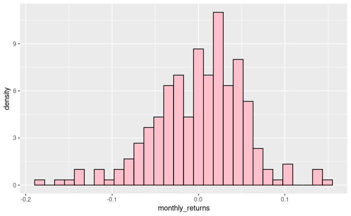

```r
monthly_returns_eurostoxx %>%
  ggplot(aes(x=monthly_returns)) +
  geom_histogram(aes(y=..density..), colour="black", fill="pink")
```

it is skewed to the left –> it is right steep , negatively skewed –> we see that in thhe skewness in table.Stats as well

but it is almost normally distributed

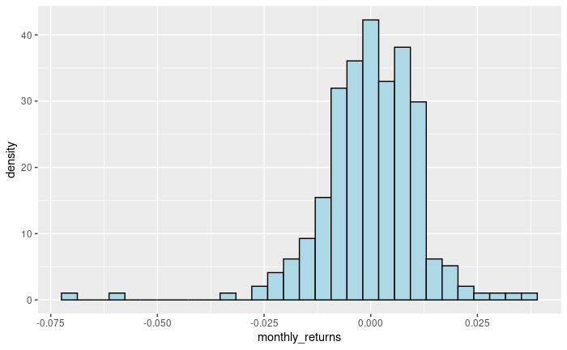

```r
monthly_returns_iboxx %>%
  ggplot(aes(x=monthly_returns)) +
  geom_histogram(aes(y=..density..), colour="black", fill="lightblue")
```

same as above

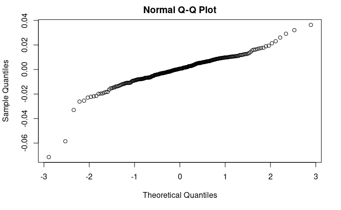

```r
qqnorm(monthly_returns_iboxx$monthly_returns)
```

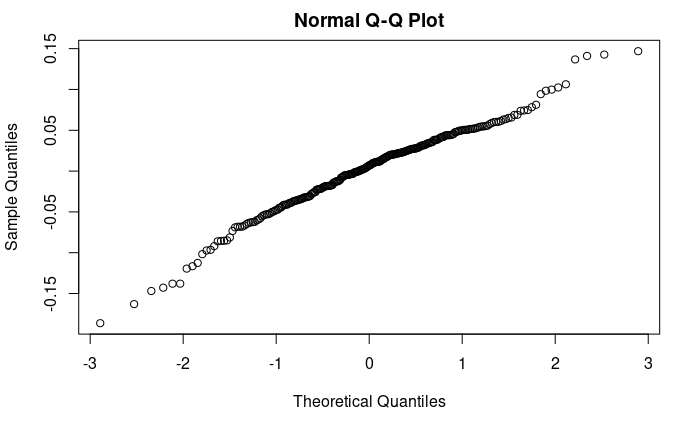

```r
qqnorm(monthly_returns_eurostoxx$monthly_returns)
```

almost a straight line

2. Get the necessary input parameters (mu, sigma, please using variables, I don’t want to see manual numbers in your code) and calculate the Minimum-Variance-Portfolio (manually in R). Then do it using the `portfolioAnalytics`-package.

Calculate “mu” for each index

```r
returns_index_final_xts
```

[output not shown]

[output cut: 207 more lines]

```
Jun 2019  1.663234e-02  5.891521e-02
Jul 2019  1.088994e-02 -1.970237e-03
Aug 2019  5.261048e-03 -1.156266e-02
Sep 2019 -8.951802e-03  4.163959e-02
Oct 2019 -4.385568e-03  9.794781e-03
Nov 2019 -3.556238e-03  2.751321e-02
Dec 2019 -2.037940e-03  1.122481e-02
Jan 2020  1.049498e-02 -2.783490e-02
Feb 2020 -5.147746e-03 -8.553304e-02
Mar 2020 -7.144084e-02 -1.629639e-01
Apr 2020  3.636265e-02  5.060275e-02
May 2020 -7.561357e-04  4.175887e-02
Jun 2020  1.095124e-02  6.028170e-02
Jul 2020  1.620734e-02 -1.847519e-02
Aug 2020  9.923274e-04  3.093390e-02
```

```r
colnames(returns_index_final_xts) <- c("iboxx", "eurostoxx")
returns_index_final_xts
```

```
                 iboxx     eurostoxx
Dec 1998  0.000000e+00  0.000000e+00
Jan 1999  9.110000e-03  6.128378e-02
Feb 1999 -2.149419e-02 -1.773537e-02
Mar 1999  5.934658e-03  2.170344e-02
Apr 1999  9.705219e-03  5.562297e-02
May 1999 -1.986200e-02 -3.417095e-02
Jun 1999 -2.222787e-02  4.386327e-02
Jul 1999 -1.843625e-02 -3.960239e-02
Aug 1999 -8.681089e-03  3.587074e-02
Sep 1999 -1.206108e-02 -2.638002e-02
Oct 1999 -1.926490e-03  6.899728e-02
Nov 1999  3.112191e-03  9.979046e-02
Dec 1999 -1.081023e-02  1.367701e-01
Jan 2000 -7.431288e-03 -4.485308e-02
Feb 2000  4.183870e-04  1.063384e-01
Mar 2000  9.993066e-03  1.291432e-02
Apr 2000 -6.570703e-03  1.036318e-02
May 2000 -4.848192e-03 -1.943118e-02
Jun 2000 -2.953949e-03 -1.067876e-02
Jul 2000  2.763714e-03 -4.382794e-03
Aug 2000 -2.734048e-03  1.021317e-02
Sep 2000  1.746628e-03 -5.022824e-02
Oct 2000 -2.659516e-03  2.894645e-02
Nov 2000  7.468714e-03 -5.286827e-02
Dec 2000  1.171858e-02 -3.693259e-03
Jan 2001  9.943660e-03  1.573846e-03
Feb 2001 -4.944376e-04 -9.644955e-02
Mar 2001  3.688608e-03 -3.099855e-02
Apr 2001 -1.111087e-02  8.124444e-02
May 2001  7.714394e-03 -2.182759e-02
Jun 2001 -1.171955e-03 -4.119345e-02
Jul 2001  1.052768e-02 -3.594000e-02
Aug 2001  6.029230e-03 -8.491267e-02
Sep 2001 -1.247326e-02 -1.194748e-01
Oct 2001  2.305284e-02  5.519829e-02
Nov 2001 -6.665688e-03  5.164102e-02
Dec 2001 -1.277723e-02  4.041801e-02
Jan 2002 -8.550023e-05 -3.569768e-02
Feb 2002 -6.252739e-03 -1.240239e-02
```

[output cut: 207 more lines]

```
Jun 2019  1.663234e-02  5.891521e-02
Jul 2019  1.088994e-02 -1.970237e-03
Aug 2019  5.261048e-03 -1.156266e-02
Sep 2019 -8.951802e-03  4.163959e-02
Oct 2019 -4.385568e-03  9.794781e-03
Nov 2019 -3.556238e-03  2.751321e-02
Dec 2019 -2.037940e-03  1.122481e-02
Jan 2020  1.049498e-02 -2.783490e-02
Feb 2020 -5.147746e-03 -8.553304e-02
Mar 2020 -7.144084e-02 -1.629639e-01
Apr 2020  3.636265e-02  5.060275e-02
May 2020 -7.561357e-04  4.175887e-02
Jun 2020  1.095124e-02  6.028170e-02
Jul 2020  1.620734e-02 -1.847519e-02
Aug 2020  9.923274e-04  3.093390e-02
```

```r
mu_returns_index_final_xts <- lapply(returns_index_final_xts, FUN=mean)
mu_returns_index_final_xts
```

```
$iboxx
[1] -1.549592e-05

$eurostoxx
[1] 0.001325238
```

Calculate “sigma” for each index

```r
sigma_returns_index_final_xts <- lapply(returns_index_final_xts,FUN=sd)
sigma_returns_index_final_xts
```

```
$iboxx
[1] 0.01161256

$eurostoxx
[1] 0.05263677
```

calculate with the package

calculate the minimum-variance-portfolio

-vignette(“portfolio_vignette”) -do not allow for short selling

```r
labels <- c("iboxx", "eurostoxx")

port_l <- portfolio.spec(assets = colnames(returns_index_final_xts), category_labels = labels)

port_l <- add.constraint(portfolio=port_l,type="long_only")

minvar <- add.objective(portfolio=port_l, type="risk", name="var")

opt_minvar <- optimize.portfolio(R=returns_index_final_xts, portfolio=minvar, optimize_method="ROI", trace=TRUE)
print(opt_minvar)
```

```
PortfolioAnalytics Optimization

Call:
optimize.portfolio(R = returns_index_final_xts, portfolio = minvar,
    optimize_method = "ROI", trace = TRUE)

Optimal Weights:
    iboxx eurostoxx
        1         0

Objective Measure:
 StdDev
0.01161
```

we would invest all in iboxx

With short selling

```r
# allow for shortselling
portf_minvar <- portfolio.spec(assets = colnames(returns_index_final_xts), category_labels = labels)
# Add full investment constraint to the portfolio object
portf_minvar <- add.constraint(portfolio=portf_minvar, type="full_investment")

minvarsh <- add.objective(portfolio=portf_minvar, type="risk", name="var")

opt_minvar <- optimize.portfolio(R=returns_index_final_xts, portfolio=minvarsh, optimize_method="ROI", trace=TRUE)
print(opt_minvar)
```

```
PortfolioAnalytics Optimization

Call:
optimize.portfolio(R = returns_index_final_xts, portfolio = minvarsh,
    optimize_method = "ROI", trace = TRUE)

Optimal Weights:
    iboxx eurostoxx
   1.0174   -0.0174

Objective Measure:
 StdDev
0.01158
```

do it manually

Calculate “mu” for each index separately to use them for calculation

```r
returns_eurostoxx <- monthly_returns_eurostoxx%>%
  select(monthly_returns)

returns_iboxx <- monthly_returns_iboxx%>%
  select(monthly_returns)

mu_iboxx <- lapply(returns_iboxx, FUN=mean)
mu_iboxx
```

```
$monthly_returns
[1] -1.549592e-05
```

```r
mu_iboxx_numeric <- as.numeric(mu_iboxx)

mu_eurostoxx <- lapply(returns_eurostoxx, FUN=mean)
mu_eurostoxx
```

```
$monthly_returns
[1] 0.001325238
```

```r
mu_eurostoxx_numeric <- as.numeric(mu_eurostoxx)
```

Calculate “sigma” for each index separately

```r
sigma_iboxx <- as.numeric(lapply(returns_iboxx, FUN=sd))
sigma_iboxx
```

```
[1] 0.01161256
```

```r
sigma_eurostoxx <- as.numeric(lapply(returns_eurostoxx, FUN=sd))
sigma_eurostoxx
```

```
[1] 0.05263677
```

```r
cor <- cor(returns_index_final_xts)
cor_xy <- cor [1,2]
cor_xy
```

```
[1] 0.2932786
```

```r
abc <- sigma_iboxx^2-(sigma_eurostoxx*sigma_iboxx*cor_xy)

covarianz_xy <- sigma_eurostoxx*sigma_iboxx*cor_xy

xyz <- sigma_eurostoxx^2+sigma_iboxx^2-(2*sigma_eurostoxx*sigma_iboxx*cor_xy)

MVP <- abc/xyz
MVP
```

```
[1] -0.01743824
```

we do not invest in eurostoxx we invest everything in iboxx and sell eurostoxx to buy more iboxx

for the minumum varianze portfolio

3. Now assume a risk-free rate of 0 and calculate the Tangency-Portfolio manually and with the `portfolioAnalytics`-package. What is the slope of the CAL? Plot a mu-sigma-diagram including all relevant information. What are your portfolio weights and weighted returns? Additionally allow for shortselling and check for changes.